# Allocation-game pilot (Prolific, Nov 2026)

Democrats split a $100k budget between Riverton (R) and Lakewood (D) after chatting with a Republican persona bot or a cats-vs-dogs control bot

Published

November 6, 2026

```r
library(tidyverse)
library(jsonlite)
library(knitr)

knitr::opts_chunk$set(dpi = 150, fig.width = 8, fig.height = 4.5)
options(knitr.kable.NA = "–")
theme_set(theme_minimal(base_size = 12) + theme(panel.grid.minor = element_blank()))

PROC <- "data/processed"
pull_log <- fromJSON("data/pull_log.json")

# Game parameters (survey-app src/lib/gameEngine.js, tag v2.1.0-allocation-game-pilot)
BUDGET <- 1e5; ALPHA <- 0.5; DELTA <- 1
W_R <- exp(DELTA / 2); W_D <- exp(-DELTA / 2)      # 1.65 and 0.61
OPT_SHARE <- 1 / (1 + exp(-DELTA / (1 - ALPHA)))    # 0.881
N_ROUNDS <- 10; PAID_MIN <- 10
GRID <- seq(0.10, 0.90, by = 0.05)
exp_rev <- function(s) BUDGET * (W_R * s^ALPHA + W_D * (1 - s)^ALPHA)
REV_EVEN <- exp_rev(0.5); REV_BEST <- max(exp_rev(GRID)); BEST_GRID <- GRID[which.max(exp_rev(GRID))]
round_bonus <- function(s) 0.1 * pmin(1, pmax(0, (exp_rev(s) - REV_EVEN) / (REV_BEST - REV_EVEN)))

COND_COLORS <- c(control = "#9ca3af", treatment = "#2563eb")
COND_LABELS <- c(control = "Control (cats-vs-dogs bot)", treatment = "Treatment (Republican persona bot)")

se <- function(x) sd(x, na.rm = TRUE) / sqrt(sum(!is.na(x)))
fmt <- function(x, d = 2) formatC(x, format = "f", digits = d)
mins <- function(ms) ms / 60000

pull_time <- ymd_hms(pull_log$pulled_at)
parts <- read_csv(file.path(PROC, "participants.csv"), show_col_types = FALSE) |>
  mutate(across(c(started_at, completed_at, game_finished_at, starts_with("ts_")), ymd_hms),
         completed = !is.na(completed_at))
rounds <- read_csv(file.path(PROC, "rounds.csv"), show_col_types = FALSE)
screen <- read_csv(file.path(PROC, "screenouts.csv"), show_col_types = FALSE)
chats <- read_csv(file.path(PROC, "chat_messages.csv"), show_col_types = FALSE)
errors <- read_csv(file.path(PROC, "client_errors.csv"), show_col_types = FALSE)
```

## Snapshot

Data pulled 2026-11-06 19:41 EST from MongoDB `twins-allocation-game` (participants, screenouts, client_errors) and the chatbot’s Postgres log. 1 test record(s) were dropped (Prolific ID starting with `TEST_`/`test_`, or `test = true`). The `testing` collection is never read.

**Design.** Democrats who pass screening are assigned to one of two 5-minute chats: a Republican persona bot (treatment) or a bot that debates cats vs dogs (control). They then play 10 rounds of a budget game for SunCell solar panels. Each round they choose `share_R`, the share of a $100,000 budget spent in Riverton County (Republican-leaning); the rest goes to Lakewood County (Democratic-leaning). Expected revenue is $100{,}000\,[1.65\,s^{0.5} + 0.61\,(1-s)^{0.5}]$, with a random luck term each round. Expected revenue peaks at `share_R` = 0.88; the best split a player can choose on the slider (10%–90% in 5% steps) is 0.90. The bonus pays up to $0.10 per round for moving from a 50/50 split toward the best split, so a 50/50 player earns $0 and a player who always chooses the best split earns $1.00.

**This is a pilot of about 20 people. Every condition comparison below is underpowered and descriptive.** Its purpose is to check that the flow, the data and the game work.

## 1. Flow and timing

```r
assigned <- parts |> filter(!orphan)
in_progress <- assigned |> filter(!completed, started_at > pull_time - minutes(30))
reason_counts <- screen |> separate_longer_delim(reasons, ";") |> count(reasons)
flow_tbl <- bind_rows(
  tibble(Step = "Reached the screening questions (any record)", Total = nrow(assigned) + nrow(screen),
         Treatment = NA, Control = NA),
  tibble(Step = "Screened out (before assignment)", Total = nrow(screen), Treatment = NA, Control = NA),
  tibble(Step = paste0("    reason: ", reason_counts$reasons), Total = reason_counts$n, Treatment = NA, Control = NA),
  assigned |> summarise(Step = "Passed screening and assigned", Total = n(),
                        Treatment = sum(condition == "treatment"), Control = sum(condition == "control")),
  assigned |> filter(completed) |>
    summarise(Step = "Completed", Total = n(),
              Treatment = sum(condition == "treatment"), Control = sum(condition == "control")),
  in_progress |> summarise(Step = "Not completed, started < 30 min before pull (likely in progress)", Total = n(),
                           Treatment = sum(condition == "treatment"), Control = sum(condition == "control")),
  assigned |> filter(!completed, !participant_id %in% in_progress$participant_id) |>
    summarise(Step = "Not completed, started >= 30 min before pull (likely abandoned)", Total = n(),
              Treatment = sum(condition == "treatment"), Control = sum(condition == "control"))
)
n_done_or_quit <- nrow(assigned) - nrow(in_progress)
completion_rate <- if (n_done_or_quit > 0) sum(assigned$completed) / n_done_or_quit else NA
kable(flow_tbl, caption = "Participant flow (counts of people). Screening happens before randomization, so screen-outs have no condition.")
```

Participant flow (counts of people). Screening happens before randomization, so screen-outs have no condition.

| Step | Total | Treatment | Control |
| --- | --- | --- | --- |
| Reached the screening questions (any record) | 22 | – | – |
| Screened out (before assignment) | 1 | – | – |
| reason: low_extremity | 1 | – | – |
| Passed screening and assigned | 21 | 10 | 11 |
| Completed | 20 | 9 | 11 |
| Not completed, started < 30 min before pull (likely in progress) | 0 | 0 | 0 |
| Not completed, started >= 30 min before pull (likely abandoned) | 1 | 1 | 0 |

People who close the study before the party-strength screen leave no record in the database (the app first writes at screen-out or at assignment), so Prolific’s own counts of returns and timeouts are the source for drop-off before screening. Every record here passed the consent screen.

**Completion rate:** 20 of the 21 assigned participants who are no longer in progress completed the study (95%).

```r
screens <- c("attention_math", "cover_story", "attention_animal", "party_id", "extremity",
             "chat_intro", "chatbot", "game_tutorial", "game", "demographics")
screen_labels <- c("Math check", "Cover story", "Animal check", "Party ID", "Party strength",
                   "Chat intro", "Chat (5 min)", "Game tutorial", "Game (10 rounds)", "Demographics")
ts_long <- assigned |>
  select(participant_id, condition, completed_at, any_of(paste0("ts_", screens))) |>
  pivot_longer(starts_with("ts_"), names_to = "screen", names_prefix = "ts_", values_to = "t") |>
  mutate(screen = factor(screen, levels = screens)) |>
  arrange(participant_id, screen) |>
  group_by(participant_id) |>
  mutate(t_next = lead(t), t_next = if_else(screen == "demographics", completed_at, t_next),
         minutes = as.numeric(difftime(t_next, t, units = "mins"))) |>
  ungroup() |> filter(!is.na(minutes))

done <- assigned |> filter(completed) |>
  mutate(total_min = mins(bot_timing_ms),
         from_math_min = as.numeric(difftime(completed_at, ts_attention_math, units = "mins")))
med_total <- median(done$total_min, na.rm = TRUE)
```

**Total time (completers, N = 20):** median 9.7 minutes from page load to submitting demographics (range 6.6–19.5); median 9.5 minutes from the consent click. Pay covers 10 minutes. The median is within the paid time.

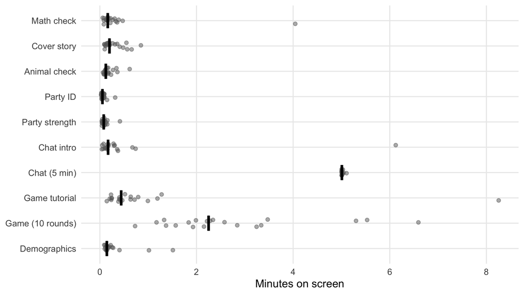

Figure 1: Minutes per screen, all assigned participants who left that screen. Grey dots are people; the black bar is the median. Times before the chat-intro screen start at the consent click.

```r
ts_long |>
  mutate(label = factor(screen_labels[as.integer(screen)], levels = rev(screen_labels))) |>
  ggplot(aes(minutes, label)) +
  geom_jitter(height = 0.15, width = 0, alpha = 0.5, colour = "grey40") +
  stat_summary(fun = median, fun.min = median, fun.max = median, geom = "crossbar", width = 0.6, colour = "black") +
  labs(x = "Minutes on screen", y = NULL)
```

```r
ts_long |> group_by(Screen = screen_labels[as.integer(screen)]) |>
  summarise(N = n(), `Median min` = fmt(median(minutes)), `Max min` = fmt(max(minutes)), .groups = "drop") |>
  arrange(match(Screen, screen_labels)) |>
  kable(caption = "Minutes per screen (N = people who left the screen).")
```

Table 1: Minutes per screen (N = people who left the screen).

| Screen | N | Median min | Max min |
| --- | --- | --- | --- |
| Math check | 21 | 0.16 | 4.04 |
| Cover story | 21 | 0.20 | 0.85 |
| Animal check | 21 | 0.12 | 0.62 |
| Party ID | 21 | 0.05 | 0.32 |
| Party strength | 21 | 0.08 | 0.42 |
| Chat intro | 20 | 0.17 | 6.12 |
| Chat (5 min) | 20 | 5.01 | 5.11 |
| Game tutorial | 20 | 0.44 | 8.25 |
| Game (10 rounds) | 20 | 2.25 | 6.59 |
| Demographics | 20 | 0.14 | 1.51 |

## 2. Data quality

```r
chat_user <- chats |> filter(!is_system_prompt)
chat_sum <- chat_user |>
  group_by(participant_id) |>
  summarise(n_msgs = sum(!is.na(message)),
            user_words = sum(str_count(coalesce(message, ""), "\\S+")),
            bot_words = sum(str_count(coalesce(response, ""), "\\S+")), .groups = "drop")
bot_served <- chats |> filter(is_system_prompt) |> distinct(participant_id, bot_prompt) |>
  group_by(participant_id) |> summarise(bot_prompt = paste(sort(unique(bot_prompt)), collapse = "+"))

qual <- assigned |>
  left_join(chat_sum, by = "participant_id") |>
  left_join(bot_served, by = "participant_id") |>
  mutate(across(c(n_msgs, user_words, bot_words), \(x) replace_na(x, 0)),
         expected_bot = if_else(condition == "treatment", "republican_persona", "cats_dogs"),
         bot_ok = coalesce(bot_prompt == expected_bot, FALSE))

qual |>
  arrange(condition, started_at) |>
  transmute(ID = str_sub(participant_id, -4), Condition = condition, Completed = completed,
            Rounds = n_rounds_saved, `Chat msgs` = n_msgs, `Chat words` = user_words,
            `Bot matches cond.` = bot_ok, `Chat timer valid` = chatbot_duration_valid,
            `Tab leaves` = n_tab_leaves, `Tab-away s` = fmt(tab_leave_total_s, 0),
            `Keys: math` = keys_math_check, `Keys: age` = keys_age, `Keys: comments` = keys_comments,
            `Keys: other` = keys_unlabeled, Pastes = n_paste,
            `Load-to-submit min` = fmt(mins(bot_timing_ms), 1)) |>
  kable(caption = "One row per assigned participant (ID = last 4 characters of the database id). Keystroke counts cover the parent page only; chat typing happens inside the chatbot iframe and is not captured.")
```

One row per assigned participant (ID = last 4 characters of the database id). Keystroke counts cover the parent page only; chat typing happens inside the chatbot iframe and is not captured.

| ID | Condition | Completed | Rounds | Chat msgs | Chat words | Bot matches cond. | Chat timer valid | Tab leaves | Tab-away s | Keys: math | Keys: age | Keys: comments | Keys: other | Pastes | Load-to-submit min |
| --- | --- | --- | --- | --- | --- | --- | --- | --- | --- | --- | --- | --- | --- | --- | --- |
| 2e0f | control | TRUE | 10 | 5 | 49 | TRUE | TRUE | 0 | 0 | 2 | 2 | 0 | 15 | 0 | 10.6 |
| 2e11 | control | TRUE | 10 | 20 | 184 | TRUE | TRUE | 2 | 9 | 4 | 2 | 0 | 12 | 0 | 8.2 |
| 2e13 | control | TRUE | 10 | 4 | 56 | TRUE | TRUE | 0 | 0 | 2 | 2 | 0 | 3 | 0 | 13.6 |
| 2e15 | control | TRUE | 10 | 3 | 166 | TRUE | TRUE | 0 | 0 | 2 | 2 | 162 | 5 | 0 | 10.2 |
| 2e17 | control | TRUE | 10 | 5 | 113 | TRUE | TRUE | 0 | 0 | 2 | 2 | 0 | 5 | 0 | 8.4 |
| 2e19 | control | TRUE | 10 | 6 | 110 | FALSE | TRUE | 0 | 0 | 4 | 2 | 0 | 4 | 0 | 6.6 |
| 2e1b | control | TRUE | 10 | 6 | 113 | TRUE | TRUE | 0 | 0 | 0 | 2 | 0 | 5 | 0 | 7.5 |
| 2e1d | control | TRUE | 10 | 3 | 144 | TRUE | TRUE | 3 | 19 | 2 | 2 | 0 | 12 | 0 | 14.2 |
| 2e1f | control | TRUE | 10 | 2 | 82 | TRUE | TRUE | 4 | 16 | 0 | 0 | 0 | 5 | 0 | 12.2 |
| 2e21 | control | TRUE | 10 | 9 | 93 | TRUE | TRUE | 0 | 0 | 2 | 2 | 0 | 3 | 0 | 9.1 |
| 2e23 | control | TRUE | 10 | 3 | 110 | TRUE | TRUE | 0 | 0 | 2 | 2 | 0 | 52 | 1 | 11.1 |
| 2e10 | treatment | TRUE | 10 | 20 | 95 | TRUE | TRUE | 0 | 0 | 2 | 2 | 0 | 3 | 0 | 8.5 |
| 2e12 | treatment | TRUE | 10 | 9 | 55 | TRUE | TRUE | 0 | 0 | 0 | 6 | 0 | 3 | 0 | 7.8 |
| 2e14 | treatment | TRUE | 10 | 3 | 115 | TRUE | TRUE | 26 | 432 | 2 | 2 | 0 | 3 | 0 | 14.7 |
| 2e16 | treatment | TRUE | 10 | 7 | 144 | TRUE | TRUE | 0 | 0 | 2 | 2 | 0 | 3 | 0 | 8.2 |
| 2e18 | treatment | FALSE | 0 | 1 | 7 | TRUE | TRUE | 0 | 0 | 0 | 0 | 0 | 0 | 0 | NA |
| 2e1a | treatment | TRUE | 10 | 11 | 204 | TRUE | TRUE | 0 | 0 | 2 | 2 | 0 | 6 | 0 | 19.5 |
| 2e1c | treatment | TRUE | 10 | 13 | 53 | TRUE | TRUE | 0 | 0 | 2 | 2 | 0 | 177 | 0 | 13.6 |
| 2e1e | treatment | TRUE | 10 | 8 | 87 | TRUE | TRUE | 0 | 0 | 2 | 2 | 0 | 5 | 0 | 10.8 |
| 2e20 | treatment | TRUE | 10 | 8 | 149 | TRUE | TRUE | 2 | 35 | 2 | 2 | 0 | 4 | 0 | 9.2 |
| 2e22 | treatment | TRUE | 10 | 4 | 65 | TRUE | TRUE | 0 | 0 | 2 | 2 | 0 | 3 | 0 | 8.8 |

```r
qs <- qual |> summarise(
  n = n(),
  missing_rounds = sum(completed & n_rounds_saved < N_ROUNDS),
  any_tab_leave = sum(n_tab_leaves > 0),
  timer_invalid = sum(chatbot_duration_valid %in% FALSE),
  bot_mismatch = sum(!bot_ok),
  no_chat = sum(n_msgs == 0),
  pastes = sum(n_paste > 0),
  honeypot = sum(!is.na(honeypot_value) & honeypot_value != ""),
  fast = sum(completed & mins(bot_timing_ms) < 6, na.rm = TRUE))
```

- **Honeypot:** 0 hits. The hidden consent field blocks a filled-in form from advancing, but the value is never sent to the server (`honeypotValue` is hard-coded to `''` in `DemographicsScreen.jsx`). A zero here is uninformative.
- **Bot timer:** `bot_timing_ms` is the time from page load to the demographics submit, so it measures total duration rather than detecting bots. 0 completer(s) finished in under 6 minutes, which is impossible with a 5-minute chat. The server-side chat timer flagged 0 participant(s) for leaving the chat before 4.5 minutes had elapsed since assignment.
- **Tab leaves:** 5 of 21 assigned participants left the tab at least once.
- **Pastes:** 1 participant(s) pressed Ctrl/Cmd+V on the parent page.
- **Chat:** 0 assigned participant(s) have no logged chat message. The bot served matched the assigned condition for 20 of 21.
- **Missing rounds:** 0 completer(s) have fewer than 10 saved rounds.

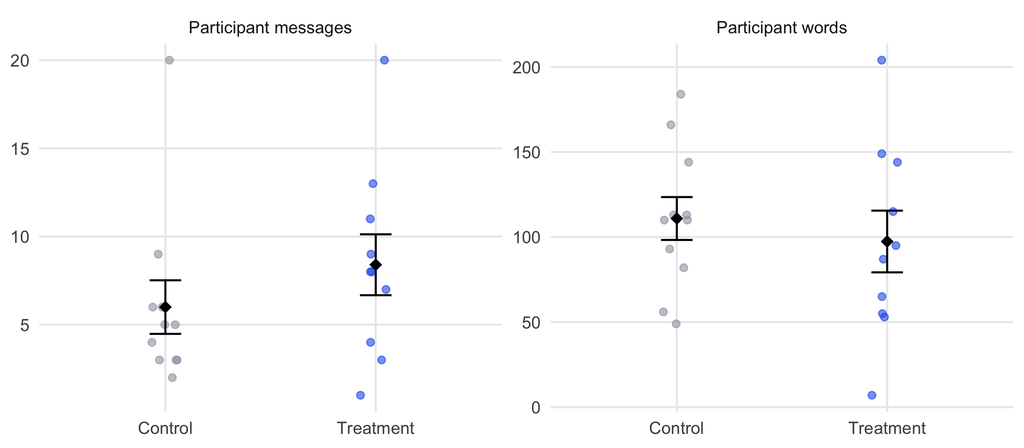

Figure 2: Chat engagement by condition, assigned participants. Dots are people; the bar is the condition mean with ±1 SE.

```r
qual |>
  select(participant_id, condition, `Participant messages` = n_msgs, `Participant words` = user_words) |>
  pivot_longer(-c(participant_id, condition)) |>
  ggplot(aes(condition, value, colour = condition)) +
  geom_jitter(width = 0.08, height = 0, alpha = 0.6) +
  stat_summary(fun.data = mean_se, geom = "errorbar", width = 0.15, colour = "black") +
  stat_summary(fun = mean, geom = "point", size = 3, shape = 18, colour = "black") +
  facet_wrap(~name, scales = "free_y") +
  scale_colour_manual(values = COND_COLORS, guide = "none") +
  scale_x_discrete(labels = c(control = "Control", treatment = "Treatment")) +
  labs(x = NULL, y = NULL)
```

## 3. Game

```r
game_ids <- assigned |> filter(n_rounds_saved == N_ROUNDS) |> pull(participant_id)
g <- rounds |>
  filter(participant_id %in% game_ids) |>
  mutate(dist_opt = abs(share_R - OPT_SHARE), exp_rev = exp_rev(share_R),
         pct_best = 100 * exp_rev / REV_BEST)
n_game <- g |> distinct(participant_id, condition) |> count(condition)
n_lab <- setNames(paste0(COND_LABELS[n_game$condition], ", N = ", n_game$n), n_game$condition)
```

The game analysis uses the 20 participants with all 10 rounds saved (control = 11, treatment = 9).

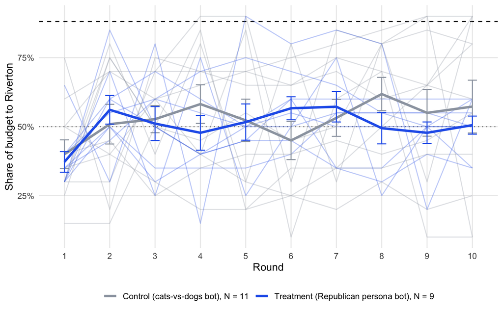

Figure 3: Share of the budget sent to Riverton (Republican-leaning county) in each round. Thin lines are individual participants; thick lines are condition means with ±1 SE. Dashed line: revenue-maximizing share (0.88). Dotted line: even split (0.50).

```r
g |>
  ggplot(aes(round, share_R, colour = condition)) +
  geom_hline(yintercept = OPT_SHARE, linetype = "dashed") +
  geom_hline(yintercept = 0.5, linetype = "dotted", colour = "grey50") +
  geom_line(aes(group = participant_id), alpha = 0.3) +
  stat_summary(fun = mean, geom = "line", linewidth = 1.3) +
  stat_summary(fun.data = mean_se, geom = "errorbar", width = 0.2) +
  scale_colour_manual(values = COND_COLORS, labels = n_lab) +
  scale_x_continuous(breaks = 1:N_ROUNDS) +
  scale_y_continuous(limits = c(0.1, 0.9), labels = scales::percent) +
  labs(x = "Round", y = "Share of budget to Riverton", colour = NULL) +
  theme(legend.position = "bottom")
```

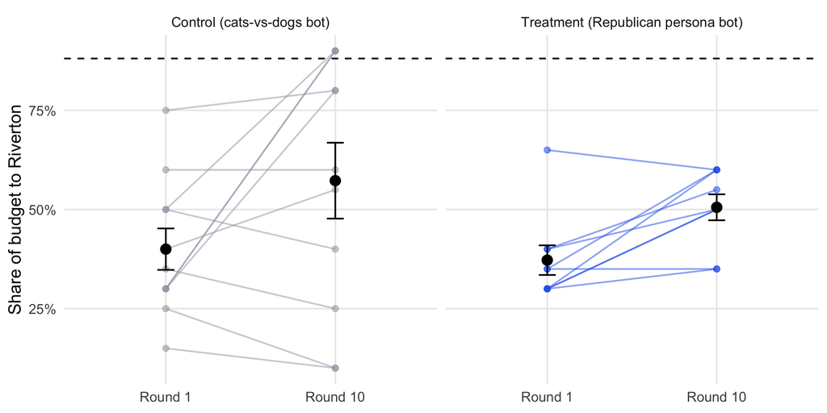

Figure 4: Share to Riverton in round 1 vs round 10. Lines connect each participant; black points are condition means with ±1 SE. Dashed line: optimum (0.88).

```r
g |> filter(round %in% c(1, N_ROUNDS)) |>
  mutate(round = factor(paste("Round", round), levels = paste("Round", c(1, N_ROUNDS)))) |>
  ggplot(aes(round, share_R, colour = condition)) +
  geom_hline(yintercept = OPT_SHARE, linetype = "dashed") +
  geom_line(aes(group = participant_id), alpha = 0.5) +
  geom_point(alpha = 0.5) +
  stat_summary(fun.data = mean_se, geom = "errorbar", width = 0.1, colour = "black") +
  stat_summary(fun = mean, geom = "point", size = 3, colour = "black") +
  facet_wrap(~condition, labeller = as_labeller(COND_LABELS)) +
  scale_colour_manual(values = COND_COLORS, guide = "none") +
  scale_y_continuous(limits = c(0.1, 0.9), labels = scales::percent) +
  labs(x = NULL, y = "Share of budget to Riverton")
```

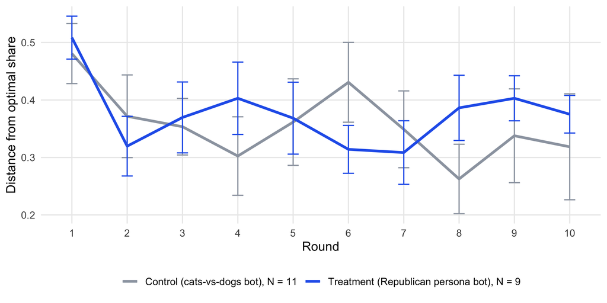

Figure 5: Distance from the optimal share (|share to Riverton − 0.88|, in share points) by round; condition means with ±1 SE. Lower is better.

```r
g |>
  ggplot(aes(round, dist_opt, colour = condition)) +
  stat_summary(fun = mean, geom = "line", linewidth = 1.2) +
  stat_summary(fun.data = mean_se, geom = "errorbar", width = 0.2) +
  scale_colour_manual(values = COND_COLORS, labels = n_lab) +
  scale_x_continuous(breaks = 1:N_ROUNDS) +
  labs(x = "Round", y = "Distance from optimal share", colour = NULL) +
  theme(legend.position = "bottom")
```

```r
person <- g |>
  group_by(participant_id, condition) |>
  summarise(mean_share = mean(share_R), r1 = share_R[round == 1], r10 = share_R[round == N_ROUNDS],
            dist = mean(dist_opt), pct_best = mean(pct_best),
            slope = coef(lm(share_R ~ round))[2], .groups = "drop") |>
  left_join(assigned |> select(participant_id, game_bonus), by = "participant_id")
msd <- function(x) paste0(fmt(mean(x)), " (", fmt(se(x)), ")")
person |> group_by(condition) |>
  summarise(N = n(), `Mean share to Riverton, rounds 1–10` = msd(mean_share),
            `Round 1 share` = msd(r1), `Round 10 share` = msd(r10),
            `Distance from 0.88` = msd(dist),
            `Expected revenue, % of best choosable` = paste0(fmt(mean(pct_best), 1), " (", fmt(se(pct_best), 1), ")"),
            `Bonus, $` = msd(na.omit(game_bonus)), .groups = "drop") |>
  mutate(condition = COND_LABELS[condition]) |>
  rename(Condition = condition) |>
  kable(caption = paste0("Game outcomes by condition: mean (SE) across participants. Share = fraction of the $100,000 budget sent to Riverton. Expected revenue excludes luck and is scaled so 100% = the best split on the slider (0.90); an even 50/50 split already earns ", fmt(100 * REV_EVEN / REV_BEST, 1), "%, so this scale is compressed. Bonus is the saved game bonus ($0–$1)."))
```

Table 2: Game outcomes by condition: mean (SE) across participants. Share = fraction of the $100,000 budget sent to Riverton. Expected revenue excludes luck and is scaled so 100% = the best split on the slider (0.90); an even 50/50 split already earns 90.8%, so this scale is compressed. Bonus is the saved game bonus ($0–$1).

| Condition | N | Mean share to Riverton, rounds 1–10 | Round 1 share | Round 10 share | Distance from 0.88 | Expected revenue, % of best choosable | Bonus, $ |
| --- | --- | --- | --- | --- | --- | --- | --- |
| Control (cats-vs-dogs bot) | 11 | 0.53 (0.04) | 0.40 (0.05) | 0.57 (0.10) | 0.36 (0.04) | 89.1 (1.9) | 0.37 (0.08) |
| Treatment (Republican persona bot) | 9 | 0.51 (0.02) | 0.37 (0.04) | 0.51 (0.03) | 0.38 (0.02) | 89.9 (0.9) | 0.22 (0.06) |

### Treatment vs control

```r
cmp <- function(var) {
  x <- person[[var]][person$condition == "treatment"]; y <- person[[var]][person$condition == "control"]
  if (length(x) < 2 || length(y) < 2) return(tibble(var, n_t = length(x), n_c = length(y), diff = mean(x) - mean(y),
                                                   lo = NA, hi = NA, p = NA, d = NA))
  tt <- t.test(x, y)  # Welch
  sp <- sqrt(((length(x) - 1) * var(x) + (length(y) - 1) * var(y)) / (length(x) + length(y) - 2))
  tibble(var, n_t = length(x), n_c = length(y), diff = mean(x) - mean(y),
         lo = tt$conf.int[1], hi = tt$conf.int[2], p = tt$p.value, d = (mean(x) - mean(y)) / sp)
}
eff <- map_dfr(c("mean_share", "slope", "dist"), cmp)
e1 <- eff[1, ]; e2 <- eff[2, ]
n_per <- min(e1$n_t, e1$n_c)
mdd <- if (n_per >= 2) power.t.test(n = n_per, power = 0.8, sig.level = 0.05)$delta else NA
eff |>
  mutate(Outcome = c("Mean share to Riverton, rounds 1–10 (share points)",
                     "Learning slope: change in share per round",
                     "Mean distance from 0.88 (share points)"),
         `N (T / C)` = paste(n_t, n_c, sep = " / "),
         `Diff (T − C)` = fmt(diff, 3), `95% CI` = if_else(is.na(lo), "n/a", paste0("[", fmt(lo, 3), ", ", fmt(hi, 3), "]")),
         p = fmt(p, 2), `Cohen's d` = fmt(d, 2)) |>
  select(Outcome, `N (T / C)`, `Diff (T − C)`, `95% CI`, p, `Cohen's d`) |>
  kable(caption = "Treatment minus control, one value per participant. Welch t-test CIs; d uses the pooled SD.")
```

Treatment minus control, one value per participant. Welch t-test CIs; d uses the pooled SD.

| Outcome | N (T / C) | Diff (T − C) | 95% CI | p | Cohen’s d |
| --- | --- | --- | --- | --- | --- |
| Mean share to Riverton, rounds 1–10 (share points) | 9 / 11 | -0.021 | [-0.126, 0.085] | 0.68 | -0.18 |
| Learning slope: change in share per round | 9 / 11 | -0.007 | [-0.024, 0.010] | 0.38 | -0.38 |
| Mean distance from 0.88 (share points) | 9 / 11 | 0.019 | [-0.086, 0.123] | 0.71 | 0.16 |

**Main pilot question.** Across rounds 1–10, treated participants (Republican persona bot, N = 9) sent on average 2.1 percentage points less of the budget to Riverton than control participants (cats-vs-dogs bot, N = 11), 95% CI [-12.6, 8.5] points. Cohen’s d = -0.18: the average treated participant’s mean share sits 0.18 standard deviations (of between-person differences in mean share) below the average control participant’s. For learning speed, the per-round change in share to Riverton differs by -0.007 share points per round (treatment − control), 95% CI [-0.024, 0.010], d = -0.38.

**The pilot is underpowered.** With 9 participants in the smaller condition, a two-sided t-test at α = .05 has 80% power only for d ≥ 1.41. The CIs above span effects of opposite sign; read the direction as a hint, not a result.

## 4. Bayesian learner

```r
fits <- read_csv(file.path(PROC, "learner_fits.csv"), show_col_types = FALSE)
rec <- read_csv(file.path(PROC, "learner_recovery.csv"), show_col_types = FALSE)
ideal <- read_csv(file.path(PROC, "learner_ideal.csv"), show_col_types = FALSE)
ideal_mc <- read_csv(file.path(PROC, "learner_ideal_mc.csv"), show_col_types = FALSE)
s_of <- function(m) pmin(0.9, pmax(0.1, 1 / (1 + exp(-m / (1 - ALPHA)))))   # split implied by belief m
N0_IDEAL <- 2 * 0.7^2 / DELTA^2
n_fit <- fits |> count(condition)
n_fit_lab <- setNames(paste0(COND_LABELS[n_fit$condition], ", N = ", n_fit$n), n_fit$condition)
r_rec <- c(mu0 = cor(rec$mu0_true, rec$mu0_hat), n0 = cor(rec$log_n0_true, rec$log_n0_hat),
           sig = cor(rec$log_sig_true, rec$log_sig_hat))
cap_learner <- c(
  paste0("Parameter recovery at the live game settings (N = ", nrow(rec), " simulated people). Each dot is one simulated person: true value (x) vs posterior mean (y). Dashed line: perfect recovery. Prior mean is in log pay-ratio units; prior strength and choice noise are on log scales."),
  paste0("Each participant's posterior mean (dot) with 80% posterior interval (thin line), by condition (N = ", nrow(fits), "). Black diamond and bar: condition mean ±1 SE across participants. Prior mean is in log pay-ratio units (0 = counties pay the same; truth = 1). Prior strength n0 and choice noise are on log10 axes."),
  paste0("Share of budget to Riverton by round. Coloured lines: participants by condition, mean ±1 SE (N = ", nrow(fits), "). Black line: ideal flat-prior Bayesian fed each person's own revenue signals, mean ±1 SE across the same ", nrow(fits), " people. Grey band: 80% range of the ideal learner over 20,000 fresh luck draws. Dashed line: optimum 0.88."))
```

**Model.** Each person holds a belief $m$ about $\theta = \log(w_R / w_D)$, how much more Riverton pays per dollar than Lakewood (truth: $\theta = 1$, so Riverton pays 2.7 times as much at the same spend). Before round 1 the belief is the **prior mean** $\mu_0$. After each round the person reads the signal $y_t = \log(\text{rev}_R / \text{rev}_D) - 0.5 \log(s_t / (1 - s_t))$, the revenue ratio with the effect of the split removed, and updates $m_{t+1} = m_t + (y_t - m_t) / (n_0 + t)$. The **prior strength** $n_0$ is the number of rounds of feedback the prior is worth: a large $n_0$ means a stubborn prior and slow learning. Each split is the revenue-maximizing split for the current belief, $1 / (1 + e^{-2m})$, plus normal **choice noise** (SD in share points), rounded to the slider’s 5% grid and capped at 0.10 and 0.90. The fit is an exact grid posterior per person (flat priors over $\mu_0 \in [-2.5, 2.5]$, $n_0 \in [0.05, 100]$, noise $\in [0.02, 0.60]$), using all 10 rounds. Code: `fit_learner_pilot.py`, which imports the learner in `studies/06_bo_pilot/fit_learner.py` and changes only the game settings and the grid likelihood. The model assumes people know the curve shape ($\alpha = 0.5$), which the game never tells them.

### Can 10 rounds identify the parameters?

Parameter recovery simulates 400 people who play the live game (δ = 1, α = 0.5, luck SD σ = 0.7, 10 rounds, 5% grid, Riverton better), with $\mu_0$, $\log n_0$ and log noise drawn from the spread of the pilot’s own estimates, then refits each one. Correlation between true and estimated values across the 400 simulated people: prior mean r = 0.72, log prior strength r = 0.67, log choice noise r = 0.91. The 80% posterior intervals contain the true $n_0$ for 75% of simulated people and the true $\mu_0$ for 74%. So 10 rounds separate people well on noise, and moderately on prior mean and prior strength: an individual’s $n_0$ is a rough ranking, and condition means are more trustworthy than single people.

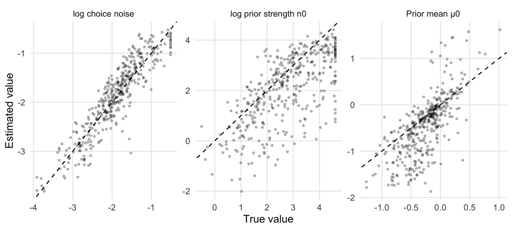

Figure 6: Parameter recovery at the live game settings (N = 400 simulated people). Each dot is one simulated person: true value (x) vs posterior mean (y). Dashed line: perfect recovery. Prior mean is in log pay-ratio units; prior strength and choice noise are on log scales.

```r
rec |>
  transmute(`Prior mean μ0` = paste(mu0_true, mu0_hat), `log prior strength n0` = paste(log_n0_true, log_n0_hat),
            `log choice noise` = paste(log_sig_true, log_sig_hat)) |>
  pivot_longer(everything()) |>
  separate(value, c("true", "hat"), sep = " ", convert = TRUE) |>
  ggplot(aes(true, hat)) +
  geom_abline(linetype = "dashed") +
  geom_point(alpha = 0.25, size = 0.8) +
  facet_wrap(~name, scales = "free") +
  labs(x = "True value", y = "Estimated value")
```

### Prior or learning: estimates by condition

```r
lcmp <- function(var, lab) {
  x <- fits[[var]][fits$condition == "treatment"]; y <- fits[[var]][fits$condition == "control"]
  tt <- t.test(x, y)
  sp <- sqrt(((length(x) - 1) * var(x) + (length(y) - 1) * var(y)) / (length(x) + length(y) - 2))
  tibble(Parameter = lab, n_t = length(x), n_c = length(y), m_t = mean(x), se_t = se(x), m_c = mean(y), se_c = se(y),
         diff = mean(x) - mean(y), lo = tt$conf.int[1], hi = tt$conf.int[2], p = tt$p.value, d = (mean(x) - mean(y)) / sp)
}
leff <- bind_rows(lcmp("mu0", "Prior mean μ0 (log Riverton/Lakewood pay ratio)"),
                  lcmp("log_n0", "log prior strength, log n0 (rounds of feedback)"),
                  lcmp("log_sig", "log choice noise (log share points)"))
leff |>
  transmute(Parameter, `N (T / C)` = paste(n_t, n_c, sep = " / "),
            `Treatment mean (SE)` = paste0(fmt(m_t), " (", fmt(se_t), ")"),
            `Control mean (SE)` = paste0(fmt(m_c), " (", fmt(se_c), ")"),
            `Diff (T − C)` = fmt(diff), `95% CI` = paste0("[", fmt(lo), ", ", fmt(hi), "]"),
            p = fmt(p, 2), `Cohen's d` = fmt(d, 2)) |>
  kable(caption = "Learner parameters by condition: mean (SE) across participants of each person's posterior mean. Treatment minus control with Welch 95% CIs; d uses the pooled SD.")
```

Learner parameters by condition: mean (SE) across participants of each person’s posterior mean. Treatment minus control with Welch 95% CIs; d uses the pooled SD.

| Parameter | N (T / C) | Treatment mean (SE) | Control mean (SE) | Diff (T − C) | 95% CI | p | Cohen’s d |
| --- | --- | --- | --- | --- | --- | --- | --- |
| Prior mean μ0 (log Riverton/Lakewood pay ratio) | 9 / 11 | -0.15 (0.06) | -0.37 (0.13) | 0.22 | [-0.09, 0.53] | 0.15 | 0.63 |
| log prior strength, log n0 (rounds of feedback) | 9 / 11 | 3.11 (0.40) | 2.58 (0.39) | 0.53 | [-0.65, 1.72] | 0.36 | 0.42 |
| log choice noise (log share points) | 9 / 11 | -2.13 (0.21) | -1.73 (0.21) | -0.40 | [-1.02, 0.23] | 0.20 | -0.60 |

```r
e_mu <- leff[1, ]; e_n0 <- leff[2, ]; e_sig <- leff[3, ]
at_ceiling <- mean(fits$log_n0_hi80 >= log(100) - 0.25)
```

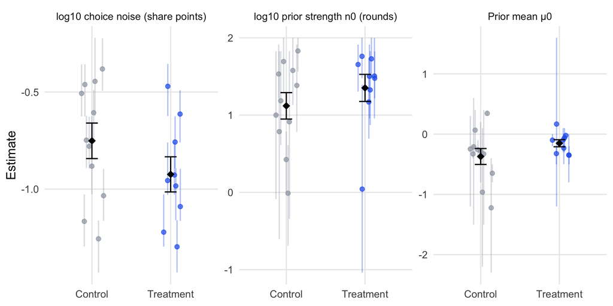

Figure 7: Each participant’s posterior mean (dot) with 80% posterior interval (thin line), by condition (N = 20). Black diamond and bar: condition mean ±1 SE across participants. Prior mean is in log pay-ratio units (0 = counties pay the same; truth = 1). Prior strength n0 and choice noise are on log10 axes.

```r
fits |>
  transmute(participant_id, condition,
            `Prior mean μ0` = paste(mu0, mu0_lo80, mu0_hi80),
            `log10 prior strength n0 (rounds)` = paste(log_n0, log_n0_lo80, log_n0_hi80),
            `log10 choice noise (share points)` = paste(log_sig, log_sig_lo80, log_sig_hi80)) |>
  pivot_longer(-c(participant_id, condition)) |>
  separate(value, c("est", "lo", "hi"), sep = " ", convert = TRUE) |>
  mutate(across(c(est, lo, hi), \(v) if_else(name == "Prior mean μ0", v, v / log(10)))) |>
  ggplot(aes(condition, est, colour = condition)) +
  geom_linerange(aes(ymin = lo, ymax = hi), position = position_jitter(width = 0.15, seed = 1), alpha = 0.35) +
  geom_point(position = position_jitter(width = 0.15, seed = 1), alpha = 0.7) +
  stat_summary(fun.data = mean_se, geom = "errorbar", width = 0.15, colour = "black") +
  stat_summary(fun = mean, geom = "point", size = 3, shape = 18, colour = "black") +
  facet_wrap(~name, scales = "free_y") +
  scale_colour_manual(values = COND_COLORS, guide = "none") +
  scale_x_discrete(labels = c(control = "Control", treatment = "Treatment")) +
  labs(x = NULL, y = "Estimate")
```

**Prior mean.** Before playing, control participants (cats-vs-dogs bot, N = 11) acted as if Lakewood paid more: mean $\mu_0$ = -0.37 (SE 0.13), a belief that Riverton pays 0.69 times what Lakewood pays, which implies sending 32% of the budget to Riverton. Treated participants (Republican persona bot, N = 9) started at $\mu_0$ = -0.15 (SE 0.06), a ratio of 0.86 and an implied split of 42% to Riverton. The difference is 0.22 log units, 95% CI [-0.09, 0.53], d = 0.63: the average treated person’s prior sits 0.63 between-person SDs closer to the truth than the average control person’s. Both groups start below 0, on the wrong side (truth = +1).

**Prior strength.** Mean $\log n_0$ was 2.58 (SE 0.39) in control and 3.11 (SE 0.40) in treatment: a typical prior worth 13 rounds of feedback in control and 22 in treatment, so round 1’s revenue moves the belief only 7% and 4% of the way to the signal. An ideal Bayesian who knows either county could be the better one has $n_0$ = 0.98. Treatment minus control = 0.53 log units, 95% CI [-0.65, 1.72], d = 0.42. For 50% of people the 80% interval reaches the top of the grid ($n_0$ = 100), so for them the data say only that the prior was very stubborn and the revenue feedback barely moved them.

**Choice noise.** Mean log noise was -1.73 in control (typical noise 18 share points) and -2.13 in treatment (12 share points); difference -0.40 log units, 95% CI [-1.02, 0.23], d = -0.60.

**Prior or learning?** In this pilot, the chatbot’s difference in where people start (prior mean, p = 0.15) is clearer than its difference in how fast they learn (prior strength, p = 0.36). **The pilot is underpowered:** with 9 people in the smaller condition, a t-test has 80% power only for d ≥ 1.41, and every CI above is wide. Read the direction as a hint for the main study, not a result.

### Is the plateau the people or the game?

```r
ideal_r10 <- ideal |> filter(round == N_ROUNDS)
ir <- ideal_r10 |> summarise(across(c(actual, flat, calibrated, own_prior_ideal_learning, neutral_prior_own_learning),
                                    list(m = mean, se = se)))
mc10 <- ideal_mc |> filter(round == N_ROUNDS)
```

An ideal Bayesian with a flat prior and no choice noise, fed the revenue each person actually saw, believes the mean of the signals so far and picks the best grid split for that belief. The share-corrected signal does not depend on the split, so the benchmark can reuse each person’s own luck draws. In round 10 that ideal learner sends 86% (SE 1.0 points, N = 20 people’s luck draws) of the budget to Riverton; people sent 54% (SE 5.4). Over 20,000 fresh luck draws the flat-prior ideal reaches 85% by round 10 (80% of games between 75% and 90%), and a calibrated ideal (prior centred on 0, $n_0$ = 0.98) reaches 84%. **The game is learnable in 10 rounds; the plateau near 54% comes from the people.**

Two counterfactuals split the gap. Keeping each person’s own prior mean but giving them ideal learning ($n_0$ = 0.98) yields 84% to Riverton in round 10 (SE 0.8). Keeping each person’s own prior strength but starting from a neutral prior ($\mu_0$ = 0) yields 66% (SE 2.3). Slow learning, more than the starting belief, holds people back.

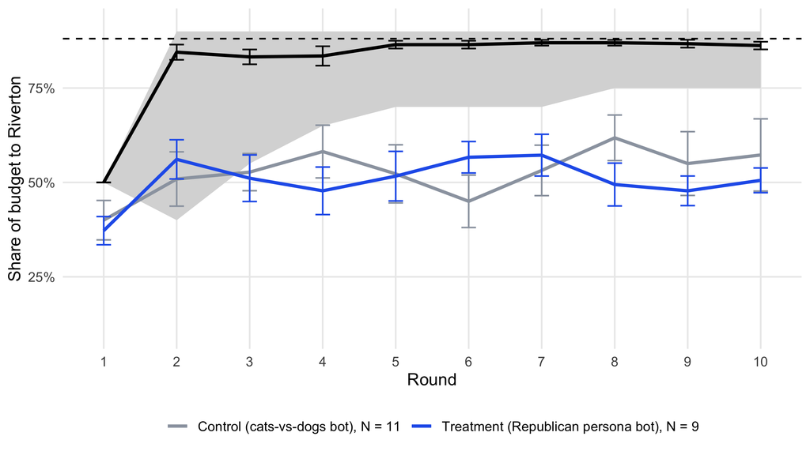

Figure 8: Share of budget to Riverton by round. Coloured lines: participants by condition, mean ±1 SE (N = 20). Black line: ideal flat-prior Bayesian fed each person’s own revenue signals, mean ±1 SE across the same 20 people. Grey band: 80% range of the ideal learner over 20,000 fresh luck draws. Dashed line: optimum 0.88.

```r
band <- ideal_mc |> filter(learner == "flat")
ideal_long <- ideal |> select(participant_id, condition, round, actual, flat)
ggplot() +
  geom_ribbon(data = band, aes(round, ymin = q10, ymax = q90), fill = "grey85") +
  geom_hline(yintercept = OPT_SHARE, linetype = "dashed") +
  stat_summary(data = ideal_long, aes(round, flat), fun = mean, geom = "line", linewidth = 1.1) +
  stat_summary(data = ideal_long, aes(round, flat), fun.data = mean_se, geom = "errorbar", width = 0.2) +
  stat_summary(data = ideal_long, aes(round, actual, colour = condition), fun = mean, geom = "line", linewidth = 1.1) +
  stat_summary(data = ideal_long, aes(round, actual, colour = condition), fun.data = mean_se, geom = "errorbar", width = 0.2) +
  scale_colour_manual(values = COND_COLORS, labels = n_fit_lab) +
  scale_x_continuous(breaks = 1:N_ROUNDS) +
  scale_y_continuous(limits = c(0.1, 0.92), labels = scales::percent) +
  labs(x = "Round", y = "Share of budget to Riverton", colour = NULL) +
  theme(legend.position = "bottom")
```

```r
learner_labels <- c(actual = "Participants (actual)", flat = "Ideal, flat prior",
                    calibrated = "Ideal, calibrated prior (μ0 = 0, n0 = 0.98)",
                    own_prior_ideal_learning = "Own prior mean, ideal learning (n0 = 0.98)",
                    neutral_prior_own_learning = "Neutral prior (μ0 = 0), own prior strength")
ideal_r10 |>
  pivot_longer(all_of(names(learner_labels))) |>
  group_by(name, condition) |>
  summarise(v = paste0(fmt(100 * mean(value), 1), " (", fmt(100 * se(value), 1), ")"), .groups = "drop") |>
  pivot_wider(names_from = condition, values_from = v) |>
  arrange(match(name, names(learner_labels))) |>
  transmute(Learner = learner_labels[name], Control = control, Treatment = treatment) |>
  kable(caption = paste0("Round-10 share of budget to Riverton, % (SE across participants); each learner is fed the person's own revenue signals. N = ", paste(n_fit$condition, n_fit$n, sep = " ", collapse = ", "), ". Optimum = 88%; best grid split = 90%."))
```

Table 3: Round-10 share of budget to Riverton, % (SE across participants); each learner is fed the person’s own revenue signals. N = control 11, treatment 9. Optimum = 88%; best grid split = 90%.

| Learner | Control | Treatment |
| --- | --- | --- |
| Participants (actual) | 57.3 (9.6) | 50.6 (3.3) |
| Ideal, flat prior | 86.4 (1.4) | 86.1 (1.6) |
| Ideal, calibrated prior (μ0 = 0, n0 = 0.98) | 84.5 (1.1) | 84.4 (1.3) |
| Own prior mean, ideal learning (n0 = 0.98) | 84.1 (1.1) | 84.4 (1.3) |
| Neutral prior (μ0 = 0), own prior strength | 68.2 (3.4) | 63.3 (2.8) |

## 5. Integrity checks

```r
r_all <- rounds |> left_join(assigned |> select(participant_id, game_bonus, game_score_R_world, completed), by = "participant_id")
order_bad <- rounds |> group_by(participant_id) |> arrange(saved_at, .by_group = TRUE) |>
  summarise(bad = any(diff(round) <= 0) | any(round != seq_along(round)))
person_all <- r_all |> group_by(participant_id) |>
  summarise(bonus_sum = round(sum(bonus), 2), game_bonus = first(game_bonus),
            score = mean(split_score), game_score = first(game_score_R_world), n = n())
yoke <- assigned |> arrange(started_at) |> group_by(condition) |>
  mutate(expected_seed = ((row_number() - 1) %/% 2) %% 100) |> ungroup()
n_yoke_bad <- sum(yoke$game_seed != yoke$expected_seed, na.rm = TRUE)
checks <- tribble(
  ~Check, ~Problems,
  "Duplicate Prolific IDs among assigned participants", sum(duplicated(assigned$prolific_pid)),
  "Prolific ID both screened out and assigned", sum(assigned$prolific_pid %in% screen$prolific_pid),
  "Duplicate Prolific IDs among screen-outs", sum(duplicated(screen$prolific_pid)),
  "Duplicate submission IDs", sum(duplicated(na.omit(assigned$submission_id))),
  "Orphan records (demographics saved without a participant record)", sum(parts$orphan),
  "Assigned but not a Democrat, or party strength < 25", sum(assigned$party != "Democrat" | assigned$extremity < 25, na.rm = TRUE),
  "Assigned on an app build other than 1ac0f92 (v2.1.0)", sum(assigned$app_commit != "1ac0f92", na.rm = TRUE),
  "Completed with fewer than 10 rounds", sum(assigned$completed & assigned$n_rounds_saved < N_ROUNDS),
  "Game finished but demographics missing (> 30 min ago)", sum(!is.na(assigned$game_finished_at) & !assigned$completed & assigned$game_finished_at < pull_time - minutes(30)),
  "Duplicate (participant, round) rows", sum(duplicated(rounds[c("participant_id", "round")])),
  "Rounds saved out of order or with gaps", sum(order_bad$bad),
  "share_R outside 0.10–0.90 or off the 5% grid", sum(rounds$share_R < 0.1 - 1e-9 | rounds$share_R > 0.9 + 1e-9 | abs(rounds$share_R * 20 - round(rounds$share_R * 20)) > 1e-6),
  "alloc_R + alloc_D != $100,000, or alloc_R != share_R x budget", sum(rounds$alloc_R + rounds$alloc_D != BUDGET | abs(rounds$alloc_R - rounds$share_R * BUDGET) > 1),
  "total_rev != rev_R + rev_D", sum(rounds$total_rev != rounds$rev_R + rounds$rev_D),
  "Round bonus differs from the bonus rule (> $0.001)", sum(abs(rounds$bonus - round_bonus(rounds$share_R)) > 1e-3),
  "Saved game bonus != sum of round bonuses (complete games)", sum(person_all$n == N_ROUNDS & abs(person_all$bonus_sum - person_all$game_bonus) > 0.011, na.rm = TRUE),
  "Saved split score != mean of round split scores (complete games)", sum(person_all$n == N_ROUNDS & abs(person_all$score - person_all$game_score) > 0.01, na.rm = TRUE),
  "Bonus outside $0–$1", sum(assigned$game_bonus < 0 | assigned$game_bonus > 1, na.rm = TRUE),
  "Age outside 18–100", sum(assigned$age < 18 | assigned$age > 100, na.rm = TRUE),
  "Chat bot served does not match assigned condition", qs$bot_mismatch,
  "Client save errors logged (non-test)", nrow(errors),
  "Luck seed differs from the yoking rule given the person's order within condition", n_yoke_bad
)
kable(checks, caption = "Integrity checks. Problems = number of people or rows that fail the check; 0 means clean.")
```

Integrity checks. Problems = number of people or rows that fail the check; 0 means clean.

| Check | Problems |
| --- | --- |
| Duplicate Prolific IDs among assigned participants | 0 |
| Prolific ID both screened out and assigned | 0 |
| Duplicate Prolific IDs among screen-outs | 0 |
| Duplicate submission IDs | 0 |
| Orphan records (demographics saved without a participant record) | 0 |
| Assigned but not a Democrat, or party strength < 25 | 0 |
| Assigned on an app build other than 1ac0f92 (v2.1.0) | 0 |
| Completed with fewer than 10 rounds | 0 |
| Game finished but demographics missing (> 30 min ago) | 0 |
| Duplicate (participant, round) rows | 0 |
| Rounds saved out of order or with gaps | 0 |
| share_R outside 0.10–0.90 or off the 5% grid | 0 |
| alloc_R + alloc_D != $100,000, or alloc_R != share_R x budget | 0 |
| total_rev != rev_R + rev_D | 0 |
| Round bonus differs from the bonus rule (> $0.001) | 0 |
| Saved game bonus != sum of round bonuses (complete games) | 0 |
| Saved split score != mean of round split scores (complete games) | 0 |
| Bonus outside $0–$1 | 0 |
| Age outside 18–100 | 0 |
| Chat bot served does not match assigned condition | 1 |
| Client save errors logged (non-test) | 0 |
| Luck seed differs from the yoking rule given the person’s order within condition | 5 |

**FLAG: yoking is off for 5 participant(s).** The server assigns the seed from the count of all records in the live participants collection for that condition, so a non-Prolific record (e.g. a preview session that ran without test=1 and got an auto-generated test_ ID) shifts every later seed in that condition by one. Pairs still face similar luck on average, but the k-th treated and k-th control participant no longer see identical revenue shocks. The balance counter for condition assignment counts the same record.

```r
assigned |> count(condition, game_seed) |>
  pivot_wider(names_from = condition, values_from = n, values_fill = 0) |>
  kable(caption = "Yoked luck seeds: the k-th treated and k-th control participant share a seed (pairs 0, 0, 1, 1, ...). Counts of people per seed.")
```

Yoked luck seeds: the k-th treated and k-th control participant share a seed (pairs 0, 0, 1, 1, …). Counts of people per seed.

| game_seed | control | treatment |
| --- | --- | --- |
| 0 | 2 | 1 |
| 1 | 2 | 2 |
| 2 | 2 | 2 |
| 3 | 2 | 2 |
| 4 | 2 | 2 |
| 5 | 1 | 1 |